# chimamas

For this analysis, only reads with a mapping quality of 10 or greater and bases with a base quality of 20 or greater were included.

```r
library(data.table)
library(tidyverse)
```

```r
vcf_file <- "~/Desktop/chimamas/merged_filtered.vcf"
reads_file <- "~/Desktop/chimamas//all_read_counts.csv"

BASES <- c("A", "C", "G", "T")

# ignore deletions, insertions etc...
vcf <- fread(vcf_file, skip = "#CHROM") %>%
    filter(REF %in% BASES,
           ALT %in% BASES) %>%
    rename(CHROM = `#CHROM`) %>%
    mutate(CHROM = paste0("chr", CHROM))

vcf_long <- vcf %>%
  select(-ID, -QUAL, -FILTER, -INFO) %>%
  gather(sample, info, -CHROM, -POS, -REF, -ALT, -FORMAT) %>%
  as.data.table()
```

```r
REL_DICT <- c(ChA = "Child", CHA = "Child", ChC = "Child",
              FA = "Father", FC = "Father", jMC = "Mother")

vcf_long2 <- copy(vcf_long)

vcf_long2[FORMAT == "GT:AD:DP:GQ:PL", c("GT", "AD", "DP", "GQ", "PL") := tstrsplit(info, ":", fixed = T)]
vcf_long2[FORMAT == "GT:DP:AD:GQ:PL", c("GT", "DP", "AD", "GQ", "PL") := tstrsplit(info, ":", fixed = T)]
vcf_long2[DP == '.', `:=`(DP = '0')]
vcf_long2[, `:=`(DP = as.numeric(DP))]
vcf_long2[, c("family", "rel") := tstrsplit(sample, "-", keep = c(1,2))]
# lose grandparent data
vcf_trios <- vcf_long2 %>%
  mutate(rel = REL_DICT[rel]) %>%
  filter(!is.na(rel))
```

```r
family_stats <- vcf_trios %>%
  group_by(family) %>%
  summarise(num_family_members = length(unique(sample)),
            has_m_f_c = all(c("Father", "Mother", "Child") %in% rel))

has_three <- family_stats %>%
  filter(has_m_f_c,
         num_family_members == 3)

chr_counts <- vcf_trios %>%
  filter(family %in% has_three$family) %>%
  filter(rel %in% c("Mother", "Father")) %>%
  group_by(family, rel, CHROM) %>%
  summarise(total_count = sum(DP))

ratio <- chr_counts %>%
  group_by(family, rel) %>%
  summarise(chrYtochr7 = 1000 * total_count[CHROM == "chrY"] / total_count[CHROM == "chr7"]) %>%
  spread(rel, chrYtochr7)
```

# SNPs in the VCF

This is a table of the chromosome of SNPs in the VCF. The unit of observation is the SNP.

```r
vcf %>%
  group_by(CHROM) %>%
  count()
```

A grouped_df: 2 × 2

| CHROM <chr> | n <int> |
| --- | --- |
| chr7 | 2888 |
| chrY | 11 |

# Trios in the VCF

Here is a table of the number of family members we have data for, against whether we have data for a child, mother and father. The unit of observation is the family.

```r
table(family_stats$num_family_members, family_stats$has_m_f_c, dnn = list("# family members", "Full trio"))
```

```
                Full trio
# family members FALSE TRUE
               1     8    0
               2     4    0
               3     0   13
```

# Check sex of parents

To check the sex of the parents we calculate the ratio of total read count for SNPs on chromosome Y to total read count for SNPs on chromosome 7 (multiplied by 1000). Here only families with data for a mother, father and child are included. Each row represents one family. There are not any sex mix-ups.

```r
ratio %>% rename(father_Y_to_7_ratio = Father, mother_Y_to_7_ratio = Mother)
```

A grouped_df: 13 × 3

| family <chr> | father_Y_to_7_ratio <dbl> | mother_Y_to_7_ratio <dbl> |
| --- | --- | --- |
| 11 | 2.176873 | 0.000000000 |
| 15 | 2.204950 | 0.000000000 |
| 16 | 6.051213 | 0.000000000 |
| 18 | 3.567871 | 0.000000000 |
| 19 | 2.981908 | 0.000000000 |
| 25 | 2.257567 | 0.000000000 |
| 26 | 5.541046 | 0.000000000 |
| 3 | 3.898588 | 0.000000000 |
| 4 | 2.666948 | 0.000000000 |
| 5 | 2.873504 | 0.001683489 |
| 7 | 3.522966 | 0.000000000 |
| 8 | 2.412392 | 0.000000000 |
| 9 | 2.504157 | 0.006506668 |

118374901 is a very noisy SNP close to lots of insertions and deletions.

```r
alt_ref <- vcf %>%
    select(CHROM, POS, VCF_REF = REF, VCF_ALT = ALT)

reads_dat <- fread(reads_file) %>%
  dplyr::select(-R) %>%
  mutate(name = gsub(".sam.sorted.bam.base.counts.txt", "", name, fixed = T),
         REF = toupper(REF)) %>%
  inner_join(alt_ref, by = c("CHROM", "POS")) %>%
  mutate(num_ref = case_when(REF == "A" ~ A,
                             REF == "C" ~ C,
                             REF == "G" ~ G,
                             REF == "T" ~ T),
         num_alt = case_when(VCF_ALT == "A" ~ A,
                             VCF_ALT == "C" ~ C,
                             VCF_ALT == "G" ~ G,
                             VCF_ALT == "T" ~ T)) %>%
  filter(!POS == 118374901)
```

```r
head(reads_dat)
```

A data.frame: 6 × 13

|  | CHROM <chr> | POS <int> | REF <chr> | DEPTH <int> | A <int> | C <int> | G <int> | T <int> | name <chr> | VCF_REF <chr> | VCF_ALT <chr> | num_ref <int> | num_alt <int> |
| --- | --- | --- | --- | --- | --- | --- | --- | --- | --- | --- | --- | --- | --- |
| 1 | chr7 | 115120325 | A | 1324 | 1322 | 1 | 0 | 1 | 10-jMC-508-19108_S34_.R1.fq.gz | A | G | 1322 | 0 |
| 2 | chr7 | 115122236 | T | 1040 | 0 | 65 | 2 | 973 | 10-jMC-508-19108_S34_.R1.fq.gz | T | C | 973 | 65 |
| 3 | chr7 | 115122238 | A | 1019 | 1015 | 1 | 2 | 1 | 10-jMC-508-19108_S34_.R1.fq.gz | A | T | 1015 | 1 |
| 4 | chr7 | 115122297 | A | 969 | 966 | 2 | 1 | 0 | 10-jMC-508-19108_S34_.R1.fq.gz | A | G | 966 | 1 |
| 5 | chr7 | 115122820 | C | 1483 | 2 | 1479 | 1 | 1 | 10-jMC-508-19108_S34_.R1.fq.gz | C | T | 1479 | 1 |
| 6 | chr7 | 115122892 | G | 1332 | 0 | 0 | 1326 | 6 | 10-jMC-508-19108_S34_.R1.fq.gz | G | A | 1326 | 0 |

# Check we don't lose SNPs after joining with the reads data

```r
reads_dat %>%
  select(CHROM, POS) %>%
  distinct() %>%
  group_by(CHROM) %>%
  count()
```

A grouped_df: 2 × 2

| CHROM <chr> | n <int> |
| --- | --- |
| chr7 | 2887 |
| chrY | 11 |

```r
all_dat <- reads_dat %>%
  select(CHROM, POS, name, num_ref, num_alt) %>%
  inner_join(vcf_trios, by = c("CHROM", "POS", name = "sample")) %>%
  select(-FORMAT, -info) %>%
  mutate(num_ref_alt = num_ref + num_alt)

chr7_dat <- all_dat %>%
  filter(CHROM == "chr7") %>%
  select(-CHROM)
```

# Overall mean depth

The overall average read depth for chromosome 7 is

```r
mean(chr7_dat$num_ref_alt)
```

1350.17520574573

# Histogram of depth across all chromosome 7 SNPs

The unit of observation is a SNP in one individual.

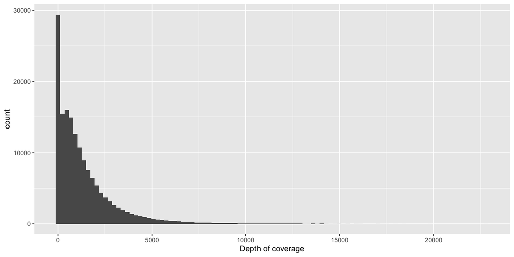

```r
ggplot(chr7_dat, aes(x=num_ref_alt)) +
  geom_histogram(bins = 100) +
  xlab("Depth of coverage")
```

# Histogram of mean depth by sample

The unit of observation is an individual.

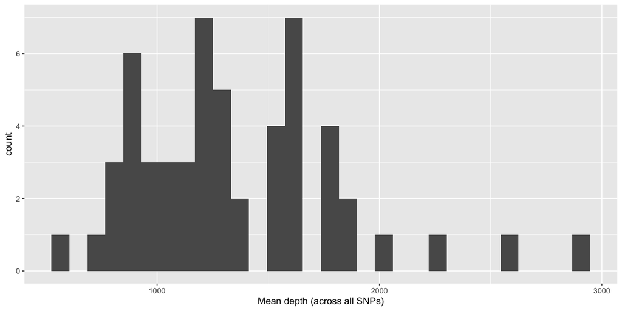

```r
mean_depth_per_sample <- chr7_dat %>%
  group_by(family, rel) %>%
  summarise(mean_num_ref_alt = mean(num_ref_alt))

mean_depth_per_sample %>%
  ggplot(aes(x=mean_num_ref_alt)) +
  geom_histogram() +
  xlab("Mean depth (across all SNPs)")


#mean_depth_per_sample %>%
#  arrange(mean_num_ref_alt) %>%
#  select(family, rel, mean_num_ref_alt) %>%
#  as.data.frame() %>%
#  print()
```

# Histogram of mean depth by SNP

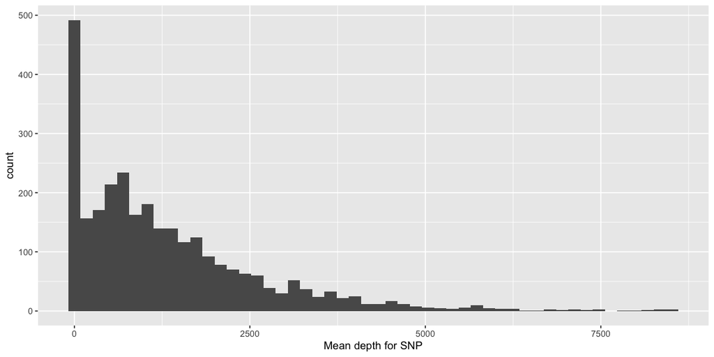

```r
chr7_dat %>%
  group_by(POS) %>%
  summarise(mean_num_ref_alt = mean(num_ref_alt)) %>%
  ggplot(aes(x=mean_num_ref_alt)) +
  geom_histogram(bins = 50) +
  xlab("Mean depth for SNP")
```

# Histogram of reference allele proportion as a function of genotype in VCF

Here the unit of observation is a SNP in one individual.

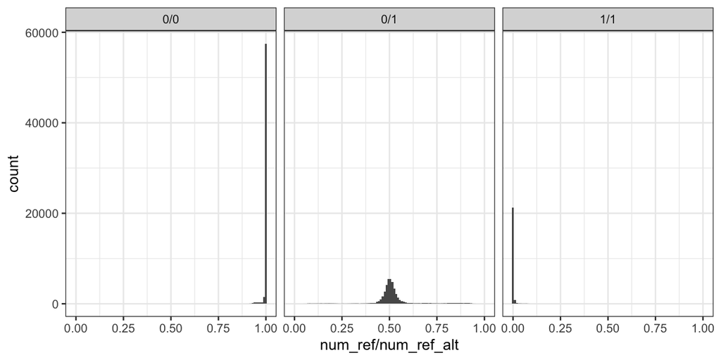

```r
options(repr.plot.width = 10, repr.plot.height = 5)

chr7_dat %>%
  filter(num_ref_alt >= 200) %>%
  ggplot(aes(x=num_ref / num_ref_alt)) +
  geom_histogram(bins = 100) +
  theme_bw(15) +
  facet_wrap(~GT)
```

A tibble: 2 × 3

| GT <chr> | More than 5 inconsistent reads (proportion) <dbl> | 1 or more inconsistent reads (proportion) <dbl> |
| --- | --- | --- |
| 0/0 | 0.08582781 | 0.5113245 |
| 1/1 | 0.09445759 | 0.5413782 |

A data.frame: 0 × 15

| POS | name | num_ref | num_alt | REF | ALT | GT | AD | DP | GQ | PL | family | rel | num_ref_alt | num_other |
| --- | --- | --- | --- | --- | --- | --- | --- | --- | --- | --- | --- | --- | --- | --- |
| <int> | <chr> | <int> | <int> | <chr> | <chr> | <chr> | <chr> | <dbl> | <chr> | <chr> | <chr> | <chr> | <int> | <int> |

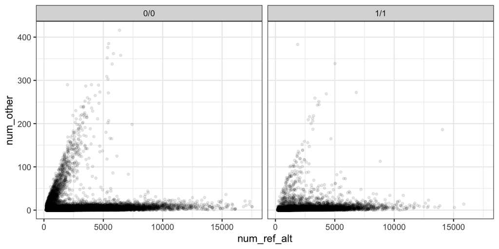

```r
other_hom_data <- chr7_dat %>%
  filter(GT %in% c('0/0', '1/1')) %>%
  filter(num_ref_alt >= 200) %>%
  mutate(num_other = if_else(GT=='0/0', num_alt, num_ref))

other_hom_data %>%
  ggplot(aes(x = num_ref_alt, y = num_other)) +
  geom_point(alpha=0.1) +
  theme_bw(15) +
  facet_wrap(~GT)

other_hom_data %>%
  group_by(GT) %>%
  summarise(`More than 5 inconsistent reads (proportion)` = mean(num_other > 5),
            `1 or more inconsistent reads (proportion)` = mean(num_other > 0))

filter(other_hom_data, num_other >= 500)
```

A grouped_df: 6 × 5

| total <dbl> | num_other <dbl> | n <int> | totalp10 <dbl> | nop10 <dbl> |
| --- | --- | --- | --- | --- |
| 200 | 0 | 172 | 210 | 10 |
| 200 | 10 | 11 | 210 | 20 |
| 210 | 0 | 293 | 220 | 10 |
| 210 | 10 | 19 | 220 | 20 |
| 220 | 0 | 290 | 230 | 10 |
| 220 | 10 | 21 | 230 | 20 |

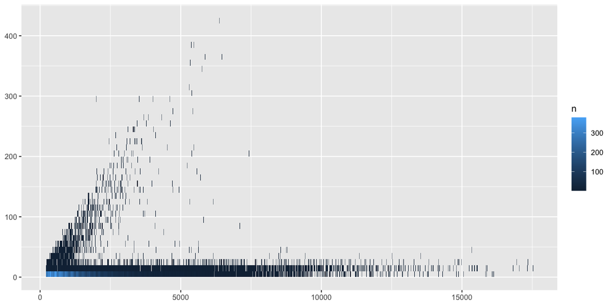

```r
oc <- other_hom_data %>%
  filter(GT == "0/0") %>%
  mutate(total = 10 * round(num_ref_alt / 10),
         num_other = 10 * round(num_other / 10)) %>%
  group_by(total, num_other) %>%
  count() %>%
  mutate(totalp10 = total + 10,
         nop10 = num_other + 10)
ggplot(oc, aes(xmin=total, xmax = totalp10, ymin=num_other, ymax = nop10, fill = n)) +
  geom_rect()
head(oc)
```

```r
filtered <- chr7_dat %>%
  filter(num_ref_alt >= 200) %>%
  filter(case_when(GT == "0/1" ~ num_ref / num_ref_alt > 0.3 & num_alt / num_ref_alt > 0.3,
                   GT == "0/0" ~ num_alt / num_ref_alt <= 0.025 & num_alt <= 20,
                   GT == "1/1" ~ num_ref / num_ref_alt <= 0.025 & num_ref <= 20))
has_all_three <- filtered %>%
  group_by(family, POS) %>%
  filter(n() == 3) %>%
  filter(!GT[rel=="Mother"] == GT[rel=="Father"]) %>%
  filter(GT[rel=="Mother"] %in% c("0/0", "1/1"),
         GT[rel=="Father"] %in% c("0/0", "1/1"))
```

Now for each family, at SNPs where both parents are homozygous and the child is heterozygous, we compare how often we see the "other" allele in the mother as opposed to the father. If there is microchimerism, we expect to see the other allele more often in mother as opposed to in father.

```r
fam <- unique(filtered$family)
par <- c("Mother", "Father")
grid <- crossing(fam, par)
res <- pmap_dfr(grid, function(fam, par, dat) {
    family_dat <- dat %>%
      filter(family == fam,
             rel %in% c(par, "Child"))
    res <- family_dat %>%
      group_by(POS) %>%
      filter(n() == 2) %>%
      summarise(child_genotype = GT[rel == "Child"],
                parent_genotype = GT[rel == par],
                parent_both_observed = num_ref[rel == par] > 0 & num_alt[rel == par] > 0,
                num_ref_par = num_ref[rel==par],
                num_alt_par = num_alt[rel==par]) %>%
      mutate(parent = par, family = fam)
}, dat = has_all_three)
```

```r
head(res)
```

A tibble: 6 × 8

| POS <int> | child_genotype <chr> | parent_genotype <chr> | parent_both_observed <lgl> | num_ref_par <int> | num_alt_par <int> | parent <chr> | family <chr> |
| --- | --- | --- | --- | --- | --- | --- | --- |
| 115138715 | 0/1 | 1/1 | TRUE | 1 | 1365 | Father | 11 |
| 115143073 | 0/1 | 1/1 | FALSE | 0 | 1926 | Father | 11 |
| 115148976 | 0/1 | 1/1 | FALSE | 0 | 393 | Father | 11 |
| 115154793 | 0/1 | 1/1 | FALSE | 0 | 1615 | Father | 11 |
| 115156835 | 0/1 | 1/1 | TRUE | 4 | 871 | Father | 11 |
| 115170750 | 0/1 | 1/1 | TRUE | 3 | 2886 | Father | 11 |

```r
summ <- res %>%
  mutate(num_ref_alt_par = num_ref_par + num_alt_par,
         num_other_par = pmin(num_ref_par, num_alt_par)) %>%
  group_by(family, parent, parent_genotype, child_genotype) %>%
  summarise(n = n(),
            n_both_observed = sum(parent_both_observed),
            mean_prop_other = mean(num_other_par / num_ref_alt_par))
```

```r
head(summ)
```

A grouped_df: 6 × 7

| family <chr> | parent <chr> | parent_genotype <chr> | child_genotype <chr> | n <int> | n_both_observed <int> | mean_prop_other <dbl> |
| --- | --- | --- | --- | --- | --- | --- |
| 11 | Father | 0/0 | 0/1 | 118 | 66 | 0.0008029060 |
| 11 | Father | 1/1 | 0/1 | 74 | 44 | 0.0010871115 |
| 11 | Mother | 0/0 | 0/1 | 74 | 35 | 0.0009536173 |
| 11 | Mother | 1/1 | 0/1 | 118 | 54 | 0.0008157856 |
| 16 | Father | 0/0 | 0/1 | 89 | 77 | 0.0030184951 |
| 16 | Father | 1/1 | 0/1 | 89 | 72 | 0.0026694419 |

```r
by_parent <- summ %>%
  group_by(family, parent) %>%
  summarise(mean_prop_other = mean(mean_prop_other),
            n_both_observed = sum(n_both_observed),
            n = sum(n),
            prop_both_observed = n_both_observed / n)
```

Here is a table, one row for each parent in the trios, of how often both alleles are observed in the parents. This is restricted to SNPs where parents have different homozygous genotypes. The proportion of such SNPs where both alleles are observed is generally higher in fathers than in mothers.

```r
by_parent
```

A grouped_df: 22 × 6

| family <chr> | parent <chr> | mean_prop_other <dbl> | n_both_observed <int> | n <int> | prop_both_observed <dbl> |
| --- | --- | --- | --- | --- | --- |
| 11 | Father | 0.0009450087 | 110 | 192 | 0.5729167 |
| 11 | Mother | 0.0008847015 | 89 | 192 | 0.4635417 |
| 16 | Father | 0.0028439685 | 149 | 178 | 0.8370787 |
| 16 | Mother | 0.0007826803 | 93 | 178 | 0.5224719 |
| 18 | Father | 0.0010518378 | 36 | 69 | 0.5217391 |
| 18 | Mother | 0.0014397920 | 35 | 69 | 0.5072464 |
| 19 | Father | 0.0013322917 | 77 | 138 | 0.5579710 |
| 19 | Mother | 0.0015055349 | 73 | 138 | 0.5289855 |
| 25 | Father | 0.0008152279 | 137 | 331 | 0.4138973 |
| 25 | Mother | 0.0009749873 | 157 | 331 | 0.4743202 |
| 26 | Father | 0.0008812794 | 110 | 222 | 0.4954955 |
| 26 | Mother | 0.0011002470 | 129 | 222 | 0.5810811 |
| 3 | Father | 0.0011893497 | 65 | 105 | 0.6190476 |
| 3 | Mother | 0.0012063601 | 59 | 105 | 0.5619048 |
| 4 | Father | 0.0009788144 | 78 | 140 | 0.5571429 |
| 4 | Mother | 0.0009760670 | 70 | 140 | 0.5000000 |
| 5 | Father | 0.0010623007 | 87 | 138 | 0.6304348 |
| 5 | Mother | 0.0010904755 | 70 | 138 | 0.5072464 |
| 8 | Father | 0.0021189265 | 130 | 194 | 0.6701031 |
| 8 | Mother | 0.0010636895 | 105 | 194 | 0.5412371 |
| 9 | Father | 0.0010698364 | 50 | 91 | 0.5494505 |
| 9 | Mother | 0.0015827314 | 48 | 91 | 0.5274725 |

```r
gt_summary <- by_parent %>%
  group_by(family) %>%
  summarise(`P(other observed) M-F` = prop_both_observed[parent == "Mother"] - prop_both_observed[parent == "Father"],
            `Mean(other allele) M-F` = mean_prop_other[parent == "Mother"] - mean_prop_other[parent == "Father"]) %>%
  mutate(`Other observed more in mother` = `P(other observed) M-F` > 0,
         `Mean(other) higher in monther ` = `Mean(other allele) M-F` > 0)
```

```r
mcnemar_pvalues <- res %>%
  split(res$family) %>%
  map_dfr(function(x) {
    x_spread <- x %>%
      select(POS, parent, parent_both_observed) %>%
      spread(parent, parent_both_observed)
    data.frame(`McNemar test pval` = round(mcnemar.test(x_spread$Father, x_spread$Mother)$p.value, 3),
              check.names = F)
  }, .id = "family")
```

This table summarises per family whether the "other" allele is more commonly observed at homozygous SNPs in mother than in father. The p value from a test for matched pairs data is also included.

```r
left_join(gt_summary, mcnemar_pvalues, by = "family")
```

A tibble: 11 × 6

| family <chr> | P(other observed) M-F <dbl> | Mean(other allele) M-F <dbl> | Other observed more in mother <lgl> | Mean(other) higher in monther <lgl> | McNemar test pval <dbl> |
| --- | --- | --- | --- | --- | --- |
| 11 | -0.10937500 | -6.030728e-05 | FALSE | FALSE | 0.036 |
| 16 | -0.31460674 | -2.061288e-03 | FALSE | FALSE | 0.000 |
| 18 | -0.01449275 | 3.879542e-04 | FALSE | TRUE | 1.000 |
| 19 | -0.02898551 | 1.732432e-04 | FALSE | TRUE | 0.708 |
| 25 | 0.06042296 | 1.597595e-04 | TRUE | TRUE | 0.111 |
| 26 | 0.08558559 | 2.189676e-04 | TRUE | TRUE | 0.065 |
| 3 | -0.05714286 | 1.701038e-05 | FALSE | TRUE | 0.429 |
| 4 | -0.05714286 | -2.747334e-06 | FALSE | FALSE | 0.382 |
| 5 | -0.12318841 | 2.817474e-05 | FALSE | TRUE | 0.054 |
| 8 | -0.12886598 | -1.055237e-03 | FALSE | FALSE | 0.009 |
| 9 | -0.02197802 | 5.128950e-04 | FALSE | TRUE | 0.860 |